# Facebook EDA

Brian Roepke

Oct 4, 2020

# Project Description

Perform Exploratory Data Analysis on the provided dataset. Refer to your reading on EDA as well as referenced resources provided in this notebook, e-learning and elsewhere. **Your project MUST include meaningful analysis with description, similar to the EDA sample provided.**

```r
library(dplyr, warn.conflicts = FALSE) # suppress conflicts warning
library(tidyr)
library(ggplot2)
library(car)
library(corrplot)
library(lsr)
library(ggcorrplot)
```

```r
fb <- read.csv("Facebook FriendsCSV.csv", skip = 2)
```

```r
str(fb)
```

```
## 'data.frame':    715 obs. of  22 variables:
##  $ Friend      : int  1 2 3 4 5 6 7 8 9 10 ...
##  $ Age         : int  57 42 42 55 30 25 28 32 29 25 ...
##  $ Photos      : chr  "7" "531" "1396" "394" ...
##  $ X..of.Tags  : int  27 241 423 139 231 345 206 581 1702 209 ...
##  $ Albums      : int  5 19 40 48 78 6 15 10 23 8 ...
##  $ Gender      : int  1 0 0 0 1 1 1 1 0 0 ...
##  $ Emp         : int  1 0 1 1 1 1 1 1 1 1 ...
##  $ Profile     : int  1 0 1 1 1 1 0 1 1 1 ...
##  $ Cover       : int  0 0 0 1 1 1 1 0 1 1 ...
##  $ Orientation : int  1 1 1 1 1 1 1 1 1 1 ...
##  $ Relationship: int  1 1 1 1 1 0 0 0 1 0 ...
##  $ Posts       : int  1 5 186 6 412 543 254 236 8 11 ...
##  $ Replies     : int  0 1 31 4 752 654 163 195 9 4 ...
##  $ MidWest     : int  0 0 1 1 1 1 1 0 1 0 ...
##  $ Seast       : int  0 0 0 0 0 0 0 0 0 0 ...
##  $ West        : int  1 1 0 0 0 0 0 0 0 1 ...
##  $ Children    : int  3 3 2 2 1 0 0 0 1 1 ...
##  $ Likes       : int  21 9 43 187 34 48 151 64 9 29 ...
##  $ Edu         : int  0 0 1 0 0 0 0 0 0 0 ...
##  $ Events      : int  0 1 1 4 2 5 1 3 2 27 ...
##  $ USA         : int  1 1 1 1 1 1 1 1 1 1 ...
##  $ Friends     : chr  "68" "234" "727" "437" ...
```

```r
names(fb)
```

```
##  [1] "Friend"       "Age"          "Photos"       "X..of.Tags"   "Albums"
##  [6] "Gender"       "Emp"          "Profile"      "Cover"        "Orientation"
## [11] "Relationship" "Posts"        "Replies"      "MidWest"      "Seast"
## [16] "West"         "Children"     "Likes"        "Edu"          "Events"
## [21] "USA"          "Friends"
```

# Data Prep

Observe the following:

- X..of..Tags column name was generated due to spaces in the column name. Rename this to Tags
- The Friend field is not a data field but represents an instance (715 in total), and is not needed
- Fields with values 0 and 1 are actually categorical (eg: Emp,Profile, Edu, Events, USA, etc..)
- Gender is categorical ((Male=1; Female=0, 2=Other/Unknown)
- Fields ‘Photos’ and ‘Friends’ were treated as character when they should be numeric. We can use regular expressions to show which values are causing the data to be treated as chr
- Remaining fields are continuous

## To Do

1. Rename ‘X of Tags’ to ‘Tags’.
2. Change the datatype from character to integer (Friends, Photos). To do this, need to remove the commas first, using gsub.

```r
# Rename ‘X of Tags’ to ‘Tags’.

fb <- rename(fb, "Tags" = "X..of.Tags")
```

```r
# Change the datatype from character to integer (Friends, Photos). To do this, need to remove the commas first, using gsub.

fb$Photos <- as.integer(gsub(",","", fb$Photos))
fb$Friends <- as.integer(gsub(",","", fb$Friends))
```

## Verify by looking at the structure again

```r
str(fb)
```

```
## 'data.frame':    715 obs. of  22 variables:
##  $ Friend      : int  1 2 3 4 5 6 7 8 9 10 ...
##  $ Age         : int  57 42 42 55 30 25 28 32 29 25 ...
##  $ Photos      : int  7 531 1396 394 916 241 138 167 922 231 ...
##  $ Tags        : int  27 241 423 139 231 345 206 581 1702 209 ...
##  $ Albums      : int  5 19 40 48 78 6 15 10 23 8 ...
##  $ Gender      : int  1 0 0 0 1 1 1 1 0 0 ...
##  $ Emp         : int  1 0 1 1 1 1 1 1 1 1 ...
##  $ Profile     : int  1 0 1 1 1 1 0 1 1 1 ...
##  $ Cover       : int  0 0 0 1 1 1 1 0 1 1 ...
##  $ Orientation : int  1 1 1 1 1 1 1 1 1 1 ...
##  $ Relationship: int  1 1 1 1 1 0 0 0 1 0 ...
##  $ Posts       : int  1 5 186 6 412 543 254 236 8 11 ...
##  $ Replies     : int  0 1 31 4 752 654 163 195 9 4 ...
##  $ MidWest     : int  0 0 1 1 1 1 1 0 1 0 ...
##  $ Seast       : int  0 0 0 0 0 0 0 0 0 0 ...
##  $ West        : int  1 1 0 0 0 0 0 0 0 1 ...
##  $ Children    : int  3 3 2 2 1 0 0 0 1 1 ...
##  $ Likes       : int  21 9 43 187 34 48 151 64 9 29 ...
##  $ Edu         : int  0 0 1 0 0 0 0 0 0 0 ...
##  $ Events      : int  0 1 1 4 2 5 1 3 2 27 ...
##  $ USA         : int  1 1 1 1 1 1 1 1 1 1 ...
##  $ Friends     : int  68 234 727 437 372 552 248 875 636 440 ...
```

## Let’s take a look at the distribution of Age.

```r
summary(fb$Age)
```

```
##    Min. 1st Qu.  Median    Mean 3rd Qu.    Max.
##   13.00   21.00   22.00   24.41   25.00   81.00
```

We see that the min Age is 13, max is 81, average is 24. For plotting, create age groups: 13–17, 18–24, 25–34, 35–44, 45–54, 55-64, 65+

Reference: https://www.statista.com/statistics/376128/facebook-global-user-age-distribution/

# Data wrangling/munging/transformation

Refers to the process of cleaning, structuring, enriching raw data into a format compatible for down stream processing such as analysis, plotting, etc. Perform the following transformations:

- Remove Friend field as it is not needed
- Convert to categorical fields to factors
  - Add AgeGroup (13–17, 18–24, 25–34, 35–44, 45–54, 55-64, 65+)
  - Update Gender values (male=1; female=0, 2=other)
  - Update Sexual Orientation values (1=heterosexual; 0=other)
  - Add InRelationship (1=yes; 0=no) and remove Relationship
  - Update Emp values (employed=1, unemployed=0)
  - Add HasCollege with yes/no: based on Edu where (1=High School or less; 0=college) then remove Edu
  - Update USA values (yes=1; no=0)
  - Add ProfilePic (1=self; 0=other) and remove Profile
  - Add CoverPic (1=self; 0=other) and remove Cover
  - Midwest, Southeast, West are represented. Update their values to be yes/no.
  - But there are observations not represented in these groups. Add a Region column with values: (MidWest, Seast,West, Other) respectively

```r
# Remove Friend field as it is not needed

fb$Friend <- NULL
```

```r
# Add AgeGroup (13–17, 18–24, 25–34, 35–44, 45–54, 55-64, 65+)

fb <- fb %>%
  mutate(AgeGroup = case_when(Age >= 13  & Age <= 17 ~ '13–17',
                              Age >= 18  & Age <= 24 ~ '18-24',
                              Age >= 25  & Age <= 34 ~ '25-34',
                              Age >= 35  & Age <= 44 ~ '35-44',
                              Age >= 45  & Age <= 54 ~ '45-54',
                              Age >= 55  & Age <= 64 ~ '55-64',
                              Age >= 65 ~ '65+'))

fb$AgeGroup <- as.factor(fb$AgeGroup)
```

```r
# Update Gender values (male=1; female=0, 2=other)

fb$Gender[fb$Gender == 1] <- 'Male'
fb$Gender[fb$Gender == 0] <- 'Female'
fb$Gender[fb$Gender == 2] <- 'Other'

fb$Gender <- as.factor(fb$Gender)
```

```r
# Update Sexual Orientation values (1=heterosexual; 0=other)

fb$Orientation[fb$Orientation == 1] <- 'Heterosexual'
fb$Orientation[fb$Orientation == 0] <- 'Other'

fb$Orientation <- as.factor(fb$Orientation)
```

```r
# Add InRelationship (1=yes; 0=no) and remove Relationship

fb <- fb %>%
  mutate(InRelationship = case_when(Relationship == 1 ~ 'Yes',
                                    Relationship == 0 ~ 'No'))

fb$InRelationship <- as.factor(fb$InRelationship)
fb$Relationship <- NULL
```

```r
# Update Emp values (employed=1, unemployed=0)

fb$Emp[fb$Emp == 1] <- 'Employed'
fb$Emp[fb$Emp == 0] <- 'Unemployed'

fb$Emp <- as.factor(fb$Emp)
```

```r
# Add HasCollege with yes/no: based on Edu where (1=High School or less; 0=college) then remove Edu

fb <- fb %>%
  mutate(HasCollege = case_when(Edu == 1 ~ 'High School or Less',
                                Edu == 0 ~ 'College'))

fb$HasCollege <- as.factor(fb$HasCollege)
fb$Edu <- NULL
```

```r
# Update USA values (yes=1; no=0)

fb$USA[fb$USA == 1] <- 'Yes'
fb$USA[fb$USA == 0] <- 'No'

fb$USA <- as.factor(fb$USA)
```

```r
# Add ProfilePic (1=self; 0=other) and remove Profile

fb <- fb %>%
  mutate(ProfilePic = case_when(Profile == 1 ~ 'Self',
                                Profile == 0 ~ 'Other'))


fb$ProfilePic <- as.factor(fb$ProfilePic)
fb$Profile <- NULL
```

```r
# Add CoverPic (1=self; 0=other) and remove Cover

fb <- fb %>%
  mutate(CoverPic = case_when(Cover == 1 ~ 'Self',
                              Cover == 0 ~ 'Other'))


fb$CoverPic <- as.factor(fb$CoverPic)
fb$Cover <- NULL
```

```r
# Midwest, Southeast, West are represented. Update their values to be yes/no.

fb$MidWest[fb$MidWest == 1] <- 'Yes'
fb$MidWest[fb$MidWest == 0] <- 'No'

fb$Seast[fb$Seast == 1] <- 'Yes'
fb$Seast[fb$Seast == 0] <- 'No'

fb$West[fb$West == 1] <- 'Yes'
fb$West[fb$West == 0] <- 'No'

fb$MidWest <- as.factor(fb$MidWest)
fb$Seast <- as.factor(fb$Seast)
fb$West <- as.factor(fb$West)
```

```r
# But there are observations not represented in these groups. Add a Region column with values: (MidWest, Seast,West, Other) respectively

fb <- fb %>%
  mutate(Region = case_when(MidWest == 'No'  & Seast == 'No' & West == 'No' ~ 'Other',
                           MidWest == 'Yes' ~ 'MidWest',
                           Seast == 'Yes' ~ 'Seast',
                           West == 'Yes' ~ 'West'))

fb$Region <- as.factor(fb$Region)
```

```r
str(fb)
```

```
## 'data.frame':    715 obs. of  23 variables:
##  $ Age           : int  57 42 42 55 30 25 28 32 29 25 ...
##  $ Photos        : int  7 531 1396 394 916 241 138 167 922 231 ...
##  $ Tags          : int  27 241 423 139 231 345 206 581 1702 209 ...
##  $ Albums        : int  5 19 40 48 78 6 15 10 23 8 ...
##  $ Gender        : Factor w/ 3 levels "Female","Male",..: 2 1 1 1 2 2 2 2 1 1 ...
##  $ Emp           : Factor w/ 2 levels "Employed","Unemployed": 1 2 1 1 1 1 1 1 1 1 ...
##  $ Orientation   : Factor w/ 2 levels "Heterosexual",..: 1 1 1 1 1 1 1 1 1 1 ...
##  $ Posts         : int  1 5 186 6 412 543 254 236 8 11 ...
##  $ Replies       : int  0 1 31 4 752 654 163 195 9 4 ...
##  $ MidWest       : Factor w/ 2 levels "No","Yes": 1 1 2 2 2 2 2 1 2 1 ...
##  $ Seast         : Factor w/ 2 levels "No","Yes": 1 1 1 1 1 1 1 1 1 1 ...
##  $ West          : Factor w/ 2 levels "No","Yes": 2 2 1 1 1 1 1 1 1 2 ...
##  $ Children      : int  3 3 2 2 1 0 0 0 1 1 ...
##  $ Likes         : int  21 9 43 187 34 48 151 64 9 29 ...
##  $ Events        : int  0 1 1 4 2 5 1 3 2 27 ...
##  $ USA           : Factor w/ 2 levels "No","Yes": 2 2 2 2 2 2 2 2 2 2 ...
##  $ Friends       : int  68 234 727 437 372 552 248 875 636 440 ...
##  $ AgeGroup      : Factor w/ 7 levels "13–17","18-24",..: 6 4 4 6 3 3 3 3 3 3 ...
##  $ InRelationship: Factor w/ 2 levels "No","Yes": 2 2 2 2 2 1 1 1 2 1 ...
##  $ HasCollege    : Factor w/ 2 levels "College","High School or Less": 1 1 2 1 1 1 1 1 1 1 ...
##  $ ProfilePic    : Factor w/ 2 levels "Other","Self": 2 1 2 2 2 2 1 2 2 2 ...
##  $ CoverPic      : Factor w/ 2 levels "Other","Self": 1 1 1 2 2 2 2 1 2 2 ...
##  $ Region        : Factor w/ 4 levels "MidWest","Other",..: 4 4 1 1 1 1 1 2 1 4 ...
```

## Verify Location values

- create a table showing the new Location values.
- show top 10 region/location values

```r
select(fb, MidWest, Seast, West, Region, USA) %>%
  head(10)
```

```
##    MidWest Seast West  Region USA
## 1       No    No  Yes    West Yes
## 2       No    No  Yes    West Yes
## 3      Yes    No   No MidWest Yes
## 4      Yes    No   No MidWest Yes
## 5      Yes    No   No MidWest Yes
## 6      Yes    No   No MidWest Yes
## 7      Yes    No   No MidWest Yes
## 8       No    No   No   Other Yes
## 9      Yes    No   No MidWest Yes
## 10      No    No  Yes    West Yes
```

```r
summary(fb$Region)
```

```
## MidWest   Other   Seast    West
##     573      49      46      47
```

## Show Top and Bottom observations

```r
head(fb)
```

```
##   Age Photos Tags Albums Gender        Emp  Orientation Posts Replies MidWest
## 1  57      7   27      5   Male   Employed Heterosexual     1       0      No
## 2  42    531  241     19 Female Unemployed Heterosexual     5       1      No
## 3  42   1396  423     40 Female   Employed Heterosexual   186      31     Yes
## 4  55    394  139     48 Female   Employed Heterosexual     6       4     Yes
## 5  30    916  231     78   Male   Employed Heterosexual   412     752     Yes
## 6  25    241  345      6   Male   Employed Heterosexual   543     654     Yes
##   Seast West Children Likes Events USA Friends AgeGroup InRelationship
## 1    No  Yes        3    21      0 Yes      68    55-64            Yes
## 2    No  Yes        3     9      1 Yes     234    35-44            Yes
## 3    No   No        2    43      1 Yes     727    35-44            Yes
## 4    No   No        2   187      4 Yes     437    55-64            Yes
## 5    No   No        1    34      2 Yes     372    25-34            Yes
## 6    No   No        0    48      5 Yes     552    25-34             No
##            HasCollege ProfilePic CoverPic  Region
## 1             College       Self    Other    West
## 2             College      Other    Other    West
## 3 High School or Less       Self    Other MidWest
## 4             College       Self     Self MidWest
## 5             College       Self     Self MidWest
## 6             College       Self     Self MidWest
```

```r
tail(fb)
```

```
##     Age Photos Tags Albums Gender        Emp  Orientation Posts Replies MidWest
## 710  25    111    8      2 Female   Employed Heterosexual    21      27      No
## 711  25    499    4      0 Female   Employed Heterosexual    16      19      No
## 712  22    232  101      4   Male Unemployed Heterosexual   698     552     Yes
## 713  22    327  329     29   Male   Employed Heterosexual   543     399     Yes
## 714  24    219    0      8   Male   Employed Heterosexual     2       7     Yes
## 715  19    465    0     22 Female   Employed Heterosexual     3       6     Yes
##     Seast West Children Likes Events USA Friends AgeGroup InRelationship
## 710    No   No        0    21      3  No     698    25-34             No
## 711    No  Yes        0    49     11 Yes    1689    25-34            Yes
## 712    No   No        0   223      4 Yes     327    18-24             No
## 713    No   No        0   520      6 Yes     706    18-24            Yes
## 714    No   No        1    66      1 Yes     500    18-24             No
## 715    No   No        0   990      3 Yes     585    18-24            Yes
##              HasCollege ProfilePic CoverPic  Region
## 710             College       Self     Self   Other
## 711             College       Self     Self    West
## 712             College       Self    Other MidWest
## 713             College       Self    Other MidWest
## 714 High School or Less       Self     Self MidWest
## 715 High School or Less       Self    Other MidWest
```

# Exploratory Data Analysis (EDA)

- Show stats, graphs and other exploratory techniques to gain insight.
- What are your questions? For example, perhaps I’m interested in understanding which variables contribute to the # of Friends. Using this information I can crearte a model that predicts the number of facebook friends.

## Display summary statistics to better understand data distributions by variable.

- For continuous variables, you have measures of dispersion such as min, max, et…
- For categorical (factors), you have counts by grouping

```r
summary(fb)
```

```
##       Age            Photos             Tags             Albums
##  Min.   :13.00   Min.   :    0.0   Min.   :    0.0   Min.   :  0.00
##  1st Qu.:21.00   1st Qu.:  124.5   1st Qu.:   75.5   1st Qu.:  6.00
##  Median :22.00   Median :  320.0   Median :  250.0   Median : 12.00
##  Mean   :24.41   Mean   :  723.9   Mean   :  458.1   Mean   : 18.95
##  3rd Qu.:25.00   3rd Qu.:  757.0   3rd Qu.:  566.5   3rd Qu.: 22.50
##  Max.   :81.00   Max.   :11995.0   Max.   :10460.0   Max.   :172.00
##
##     Gender            Emp            Orientation      Posts
##  Female:335   Employed  :533   Heterosexual:684   Min.   :  0.00
##  Male  :373   Unemployed:182   Other       : 31   1st Qu.:  6.00
##  Other :  7                                       Median : 15.00
##                                                   Mean   : 37.58
##                                                   3rd Qu.: 29.50
##                                                   Max.   :794.00
##
##     Replies       MidWest   Seast      West        Children
##  Min.   :  0.00   No :142   No :669   No :668   Min.   :0.0000
##  1st Qu.:  5.00   Yes:573   Yes: 46   Yes: 47   1st Qu.:0.0000
##  Median : 14.00                                 Median :0.0000
##  Mean   : 34.82                                 Mean   :0.2112
##  3rd Qu.: 29.00                                 3rd Qu.:0.0000
##  Max.   :752.00                                 Max.   :5.0000
##
##      Likes            Events         USA         Friends        AgeGroup
##  Min.   :   0.0   Min.   :  0.000   No : 65   Min.   :   3.0   13–17: 25
##  1st Qu.:  21.0   1st Qu.:  1.000   Yes:650   1st Qu.: 302.0   18-24:457
##  Median :  59.0   Median :  4.000             Median : 563.0   25-34:175
##  Mean   : 144.8   Mean   :  8.853             Mean   : 695.9   35-44: 35
##  3rd Qu.: 145.0   3rd Qu.:  9.000             3rd Qu.: 893.5   45-54: 17
##  Max.   :2619.0   Max.   :396.000             Max.   :4999.0   55-64:  5
##                                                                65+  :  1
##  InRelationship               HasCollege  ProfilePic   CoverPic       Region
##  No :363        College            :524   Other: 59   Other:352   MidWest:573
##  Yes:352        High School or Less:191   Self :656   Self :363   Other  : 49
##                                                                   Seast  : 46
##                                                                   West   : 47
##
##
##
```

## Graphs and plots

### Univariant

We will start to inspect this dataset across different columns to better understand the distributions of different fields.

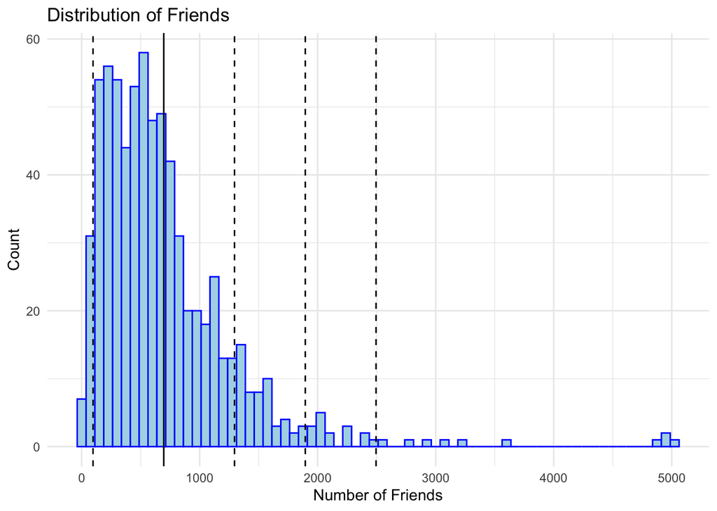

```r
fb %>%
    ggplot(aes(Friends)) +
    geom_histogram(binwidth = 75, color = "blue",fill = "lightblue") +
    geom_vline(xintercept = mean(fb$Friends), lwd = 0.5) +
    geom_vline(xintercept = mean(fb$Friends)-sd(fb$Friends), linetype="dashed") +
    geom_vline(xintercept = mean(fb$Friends)+sd(fb$Friends), linetype="dashed") +
    geom_vline(xintercept = mean(fb$Friends)+2*sd(fb$Friends), linetype="dashed") +
    geom_vline(xintercept = mean(fb$Friends)+3*sd(fb$Friends), linetype="dashed") +
    labs(title = "Distribution of Friends",
         x = "Number of Friends",
         y = "Count") +
    theme_minimal() +
    scale_x_continuous(breaks = seq(0,5000,1000))
```

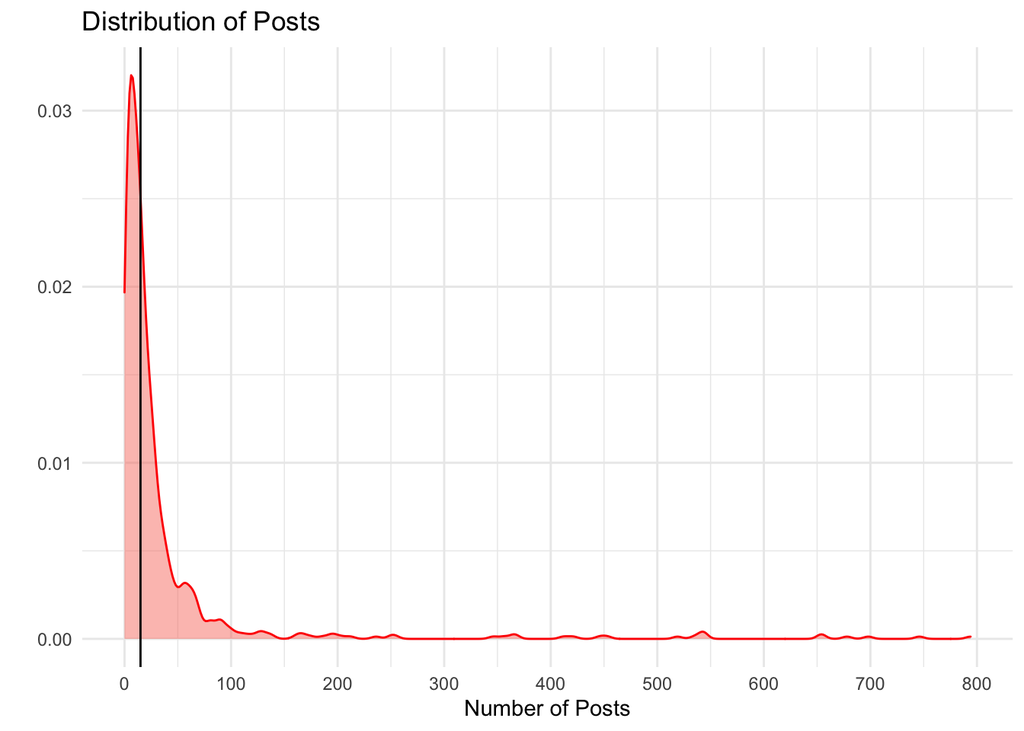

```r
fb %>%
    ggplot(aes(Posts)) +
    geom_density(color = "red",fill = "salmon", alpha=0.5) +
    geom_vline(xintercept = median(fb$Posts), lwd = 0.5) +
    labs(title = "Distribution of Posts",
         x = "Number of Posts",
         y = "") +
    theme_minimal() +
    scale_x_continuous(breaks = seq(0,800,100))
```

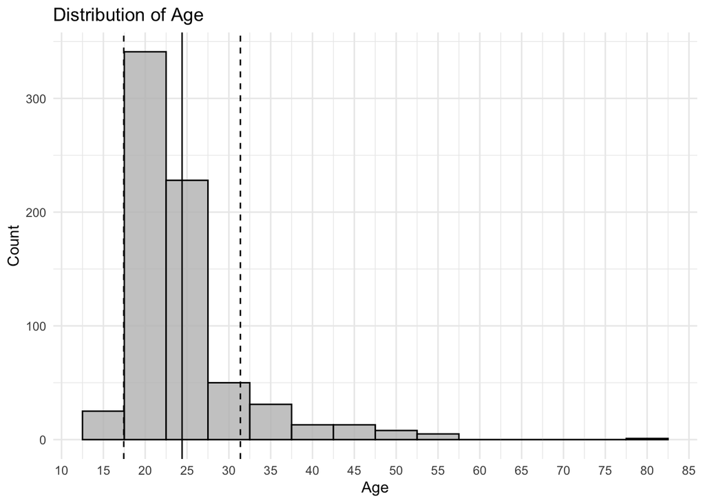

```r
fb %>%
    ggplot(aes(Age)) +
    geom_histogram(binwidth = 5, color = "black",fill = "gray", alpha=0.8) +
    geom_vline(xintercept = mean(fb$Age), lwd = 0.5) +
    geom_vline(xintercept = mean(fb$Age)-sd(fb$Age), linetype="dashed") +
    geom_vline(xintercept = mean(fb$Age)+sd(fb$Age), linetype="dashed") +
    labs(title = "Distribution of Age",
         x = "Age",
         y = "Count") +
    theme_minimal() +
    scale_x_continuous(breaks = seq(10,100,5))
```

For the distribution of people in this dataset according to age, we can see that most people are in their `20's` with the next most common in their `30's`.

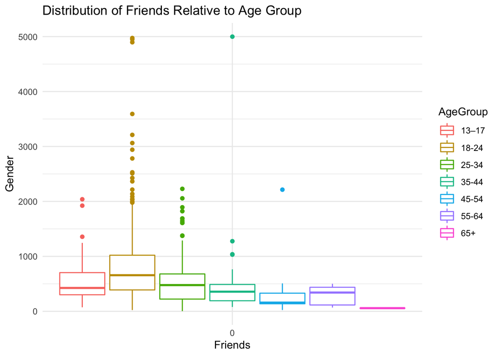

```r
fb %>%
    ggplot(aes(Friends, color = AgeGroup)) +
    geom_boxplot() +
    labs(title = "Distribution of Friends Relative to Age Group",
         x = "Gender",
         y = "Friends") +
    theme_minimal() +
    scale_y_continuous(breaks = seq(0,5000,1000)) +
    coord_flip()
```

The number of `Friends` for each `Age Group` is displayed in the box and whisker plots. People in the age group `18-24` show the largest Inner Quartile Range (IQR) as well as the most outliers with larger friend counts. This age group, `18-24`, also shows the highest mean number of `Friends`.

### Multivariate

Next we’ll further inspect the dataset to better understand the **relationship** between different variables. First starting with `Friends` and `Posts`.

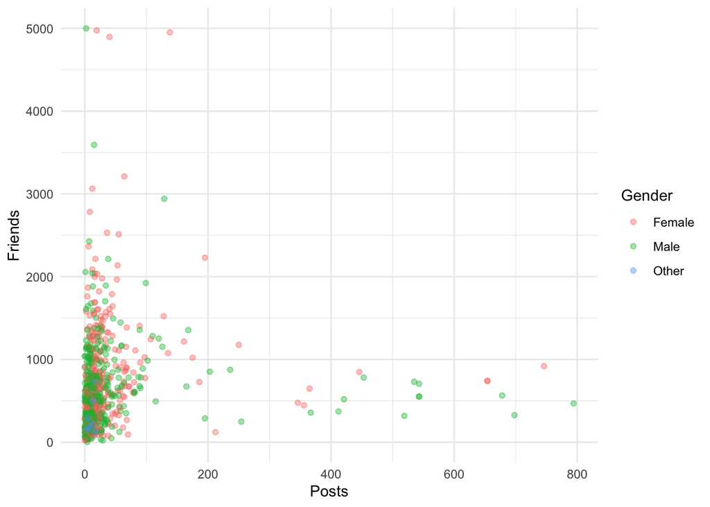

```r
ggplot(fb, mapping = aes(x = Posts, y = Friends, color = Gender)) +
  geom_point(alpha = 0.4) +
  theme_minimal()
```

For each person in the data set, plotting the number of posts they have vs. the number of friends shows a a high level of concentration below about 1500 friends and below 70-100 posts. There are a few outliers however that either have a lot of posts and a smaller amout of friends and vice versa. This dataset does not show entries that have a high amount of both friends and posts.

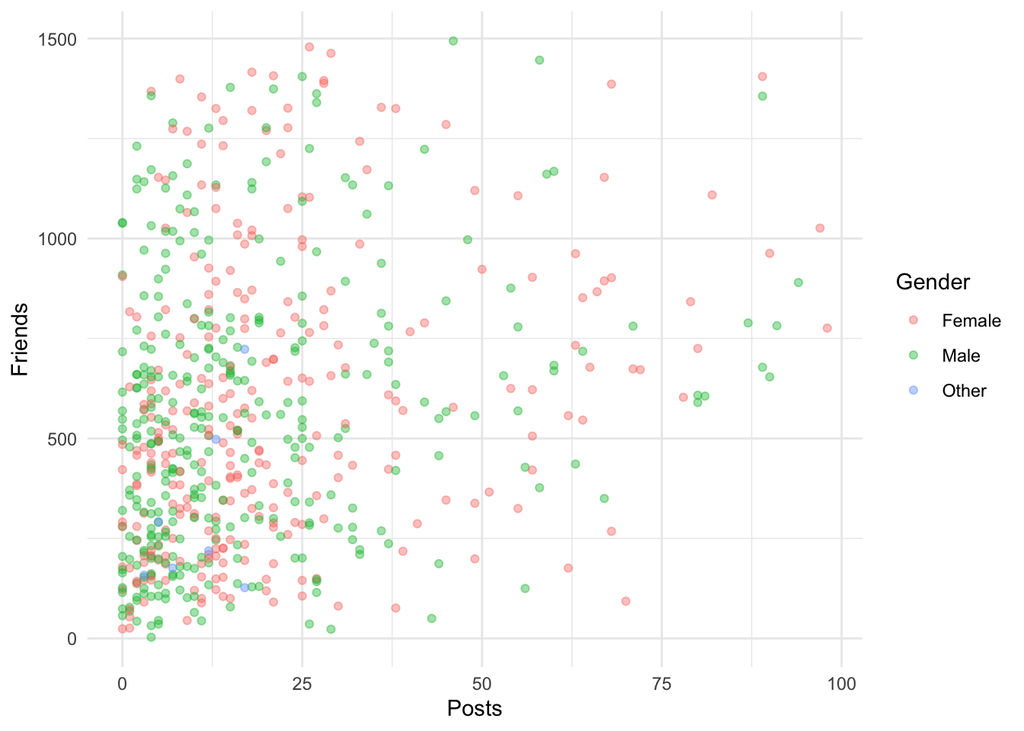

```r
fb %>% filter(Posts <= 100 & Friends <= 1500) %>%
  ggplot(mapping = aes(x = Posts, y = Friends, color = Gender)) +
  geom_point(alpha = 0.4) +
  theme_minimal()
```

Taking a look at the same data but filtered for those ranges stated above. We get a better view of the distribution. The data has a **slight positive correlation**, but not a strong one.

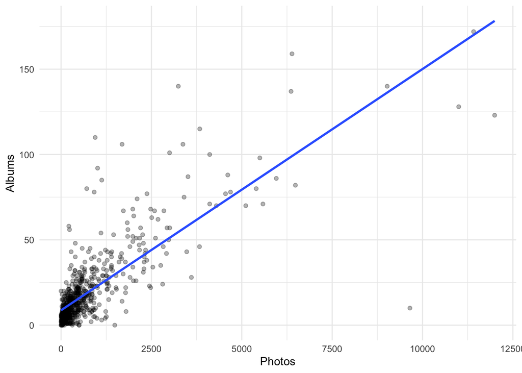

```r
ggplot(fb, mapping = aes(x = Photos, y = Albums)) +
  geom_point(color = 'black', alpha = 0.3) +
  geom_smooth(method = "lm", se = FALSE, formula = y ~ x) +
  theme_minimal()
```

When looking at the number of `Photos` posted, we can see a **positive correlation** to the number of `Albums` a person has, showin a fairly strong relationship between the two. This makes sense as people are organizing their photos by album online.

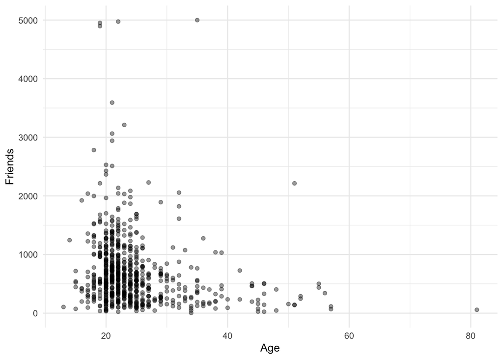

```r
ggplot(fb, mapping = aes(x = Age, y = Friends)) +
  geom_point(color = 'black', alpha = 0.4) +
  theme_minimal()
```

Here we see `Age` on the `X` axis and `Friends` on the `Y`. We can see that people starting at about age `20` to about age `30` represent a large concentration of the people in this dataset, and as the data also shows, they tend to have more Friends, or even represent the extreme Friend counts.

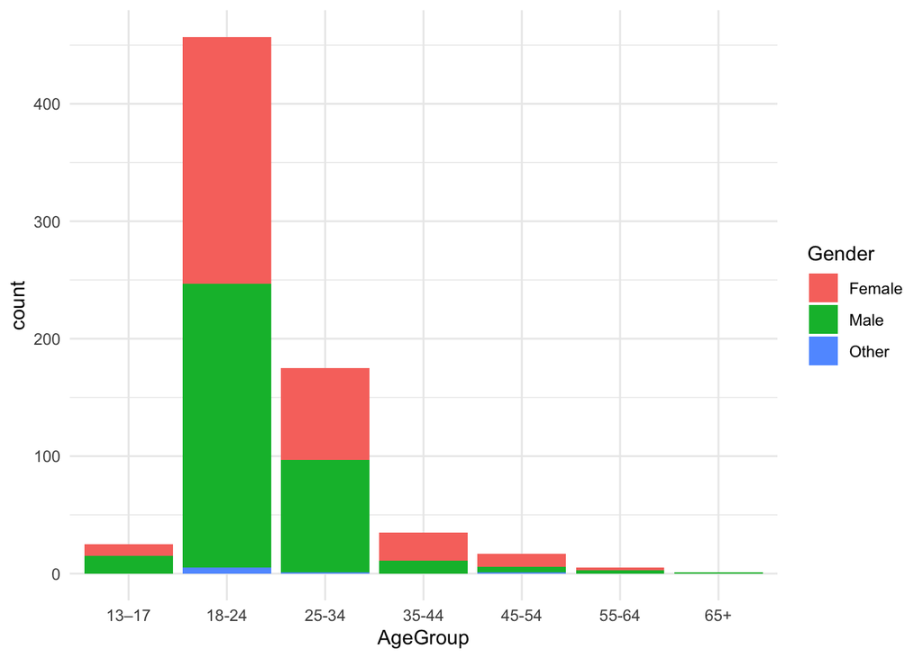

```r
fb %>%
    ggplot(aes(AgeGroup)) +
    geom_bar(aes(fill = Gender)) +
    theme_minimal()
```

### Regression Analysis

Now that we’ve conducted EDA, we will create regression model(s) to predict some continuous value. Eg: predict the ‘# of Friends’.

- Create a multiple linear regression model to predict ‘# of friends’ with only continuous predictor variables (x).
- Select which x variables should be used in the regression model given correlation analysis. DO NOT split the dataset (use all) and no need to call predict. Only create the model, show its summary and speak to the model equation and what it means.
- Refer to references and lecture notes

```r
fb2 = fb %>%
  select_if(is.numeric)
 str (fb2)
```

```
## 'data.frame':    715 obs. of  10 variables:
##  $ Age     : int  57 42 42 55 30 25 28 32 29 25 ...
##  $ Photos  : int  7 531 1396 394 916 241 138 167 922 231 ...
##  $ Tags    : int  27 241 423 139 231 345 206 581 1702 209 ...
##  $ Albums  : int  5 19 40 48 78 6 15 10 23 8 ...
##  $ Posts   : int  1 5 186 6 412 543 254 236 8 11 ...
##  $ Replies : int  0 1 31 4 752 654 163 195 9 4 ...
##  $ Children: int  3 3 2 2 1 0 0 0 1 1 ...
##  $ Likes   : int  21 9 43 187 34 48 151 64 9 29 ...
##  $ Events  : int  0 1 1 4 2 5 1 3 2 27 ...
##  $ Friends : int  68 234 727 437 372 552 248 875 636 440 ...
```

```r
corr <- round(cor(fb2), 2)
corr
```

```
##            Age Photos  Tags Albums Posts Replies Children Likes Events Friends
## Age       1.00  -0.09 -0.13  -0.04 -0.03   -0.04     0.57 -0.17   0.01   -0.20
## Photos   -0.09   1.00  0.53   0.79  0.06    0.07    -0.10  0.12   0.07    0.25
## Tags     -0.13   0.53  1.00   0.55  0.06    0.09    -0.11  0.07   0.04    0.24
## Albums   -0.04   0.79  0.55   1.00  0.11    0.13    -0.08  0.15   0.04    0.23
## Posts    -0.03   0.06  0.06   0.11  1.00    0.93    -0.05  0.04  -0.04    0.05
## Replies  -0.04   0.07  0.09   0.13  0.93    1.00    -0.06  0.04  -0.04    0.03
## Children  0.57  -0.10 -0.11  -0.08 -0.05   -0.06     1.00 -0.10   0.03   -0.16
## Likes    -0.17   0.12  0.07   0.15  0.04    0.04    -0.10  1.00   0.05    0.23
## Events    0.01   0.07  0.04   0.04 -0.04   -0.04     0.03  0.05   1.00    0.07
## Friends  -0.20   0.25  0.24   0.23  0.05    0.03    -0.16  0.23   0.07    1.00
```

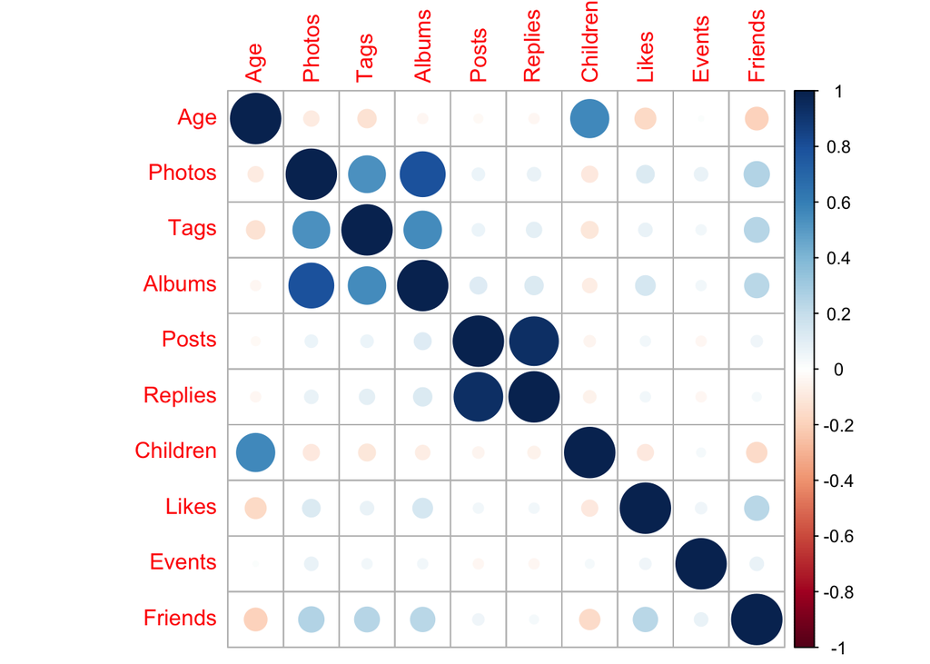

```r
corrplot(corr)
```

None of the predictor variables show a strong relationship to the response variable Friends. Of these, Photos (.25), # of Tags (.24), Albums (.23) and Likes (.23) are the strongest. Age (-20) and Children (-16) both have a weak negative correlation. While there appears to be weak correlation over all, these are the strongest and will be further analyzed as to their affect on Friends.

Further there are a number of predictor variables that correlate to each other. For example # of Tags, Photos and Albums are moderately correlated. Similarly Posts and Replies are correlated as is Children and Age. To assess the level of multicollinearity let’s compute the variance inflation factor (VIF)

```r
car::vif(lm(Friends ~., data = fb2))
```

```
##      Age   Photos     Tags   Albums    Posts  Replies Children    Likes
## 1.539842 2.841228 1.506783 2.986534 7.143445 7.181079 1.500248 1.059222
##   Events
## 1.011757
```

We’re going to create a simple linear regression between `Age` and `Friends` to get a baseline `R-squared` value for our dataset. Based on the EDA above, there seems to be the decent relationship between the age of a person and the number of friends they have.

```r
model <- lm(Friends ~ Age, data = fb2)
summary(model)
```

```
##
## Call:
## lm(formula = Friends ~ Age, data = fb2)
##
## Residuals:
##    Min     1Q Median     3Q    Max
## -785.7 -369.0 -127.1  191.3 4484.1
##
## Coefficients:
##             Estimate Std. Error t value Pr(>|t|)
## (Intercept) 1112.765     80.137   13.89  < 2e-16 ***
## Age          -17.082      3.157   -5.41 8.61e-08 ***
## ---
## Signif. codes:  0 '***' 0.001 '**' 0.01 '*' 0.05 '.' 0.1 ' ' 1
##
## Residual standard error: 588 on 713 degrees of freedom
## Multiple R-squared:  0.03943,    Adjusted R-squared:  0.03809
## F-statistic: 29.27 on 1 and 713 DF,  p-value: 8.606e-08
```

Using only age we get an `R-squared` value of `0.039` telling us that only `4%` of the variance is explained by age alone. Not a good model based on these results. We will build a Multiple Regression model to see if we can improve on that.

## Multiple regression model

Given the VIF for `Posts`, and `Replies` is greater than `5`, we will eliminate them from the model. Next, we can see which variables have a *significant* effect on the model.

```r
model <- lm(Friends ~ Age + Photos + Tags + Albums + Children + Likes + Events, data = fb2)
summary(model)
```

```
##
## Call:
## lm(formula = Friends ~ Age + Photos + Tags + Albums + Children +
##     Likes + Events, data = fb2)
##
## Residuals:
##     Min      1Q  Median      3Q     Max
## -1177.7  -333.3  -106.3   164.7  4431.9
##
## Coefficients:
##              Estimate Std. Error t value Pr(>|t|)
## (Intercept) 766.07273   93.04340   8.233 8.77e-16 ***
## Age          -9.44485    3.72154  -2.538  0.01137 *
## Photos        0.05533    0.02782   1.988  0.04715 *
## Tags          0.10397    0.03557   2.923  0.00358 **
## Albums        0.78518    1.59772   0.491  0.62327
## Children    -51.15011   39.28024  -1.302  0.19328
## Likes         0.40686    0.08226   4.946 9.46e-07 ***
## Events        1.08702    0.87523   1.242  0.21466
## ---
## Signif. codes:  0 '***' 0.001 '**' 0.01 '*' 0.05 '.' 0.1 ' ' 1
##
## Residual standard error: 558.7 on 707 degrees of freedom
## Multiple R-squared:  0.1401, Adjusted R-squared:  0.1316
## F-statistic: 16.45 on 7 and 707 DF,  p-value: < 2.2e-16
```

Upon inspecting the resulting `p-values` for the different variables after running that multiple regression model, we can see that `Albums`, `Children`, and `Events` are not significant. We can simplify the model by removing them. The R-squared value for this model is `0.14`, telling us that `14%` of the variance in the data is described with these independent variables on the dependent `Friends` variable.

```r
model <- lm(Friends ~ Age + Photos + Tags + Likes, data = fb2)
summary(model)
```

```
##
## Call:
## lm(formula = Friends ~ Age + Photos + Tags + Likes, data = fb2)
##
## Residuals:
##     Min      1Q  Median      3Q     Max
## -1221.2  -327.9  -106.1   172.5  4471.0
##
## Coefficients:
##              Estimate Std. Error t value Pr(>|t|)
## (Intercept) 827.87677   82.98748   9.976  < 2e-16 ***
## Age         -11.93533    3.06610  -3.893 0.000108 ***
## Photos        0.06748    0.01958   3.447 0.000600 ***
## Tags          0.10946    0.03436   3.185 0.001509 **
## Likes         0.41635    0.08166   5.099 4.39e-07 ***
## ---
## Signif. codes:  0 '***' 0.001 '**' 0.01 '*' 0.05 '.' 0.1 ' ' 1
##
## Residual standard error: 558.8 on 710 degrees of freedom
## Multiple R-squared:  0.136,  Adjusted R-squared:  0.1311
## F-statistic: 27.94 on 4 and 710 DF,  p-value: < 2.2e-16
```

### Summary

After running the final linear model, we will use a combination of `Age`, `Photots`, `Tags`, and `Likes` to build a predictor for `Friends`. The R-squared value is 0.136 telling us that 13.6% of the variance in the predicted number of Friends is explained by number number `Photots`, `Tags`, and `Likes` and the person’s `Age`. This is an improvement of over 9% from the simple linear model of just `Friends` and `Age`. However it’s still not a strong predictor.

With this, we can state that this model **is not a sufficient predictor** of the number of Friends someone will have.

**The linear equation is:**

`Y = 827.87677 - 11.93533(Age) + 0.06748(Photos) + 0.10946(Tags) + 0.41635(Likes)`

Brian Roepke Data 104 broepke@my.ggu.edu